# Session 4: Summarizing Data

This RMarkdown notebook generates the examples used for Session 4.

#### Frequency distribution example

```r
# create a list of the data from the lecture slides
df <- data.frame(value=c(1, 1,  2,  3,  3,  3,  3,  4,  4,  4))

# first compute the frequency distribution using the table() function

freqdist <- table(df)
print(freqdist)
```

```
## df
## 1 2 3 4
## 2 1 4 3
```

Compute the cumulative distribution

```r
cumulative_freq <- cumsum(table(df))
print(cumulative_freq)
```

```
##  1  2  3  4
##  2  3  7 10
```

Draw a histogram of the frequency distribution

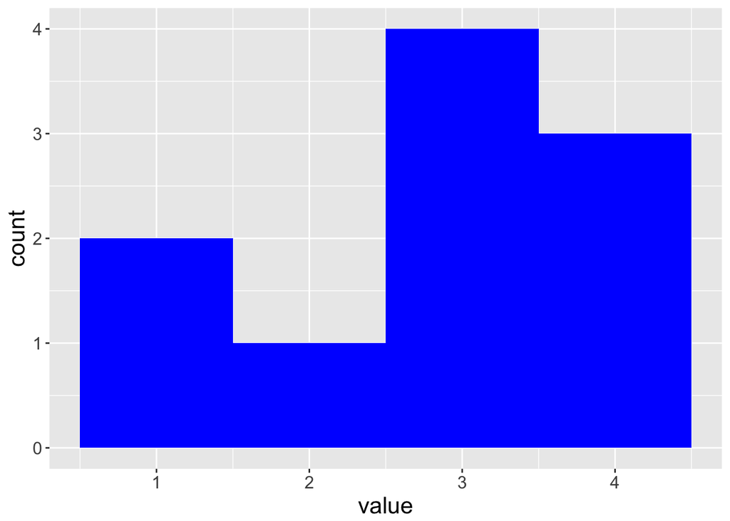

```r
t=theme(axis.text=element_text(size=12),axis.title=element_text(size=16))
ggplot(df, aes(value)) +
  geom_histogram(binwidth=1,fill='blue') + t
```

Draw a frequency polygon for the frequency distribution

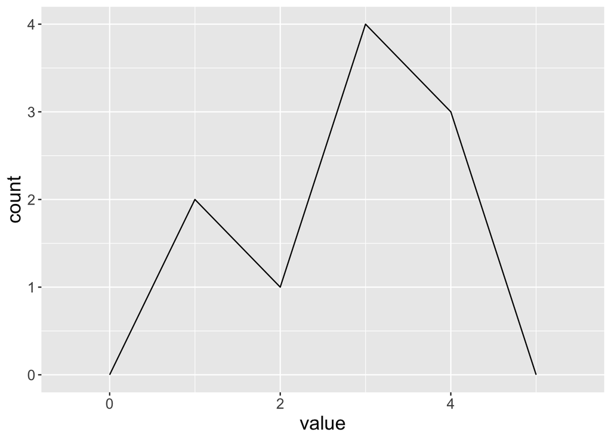

```r
ggplot(df, aes(value)) +
  geom_freqpoly(binwidth=1) +t
```

Plot frequency polygon with density rather than frequency

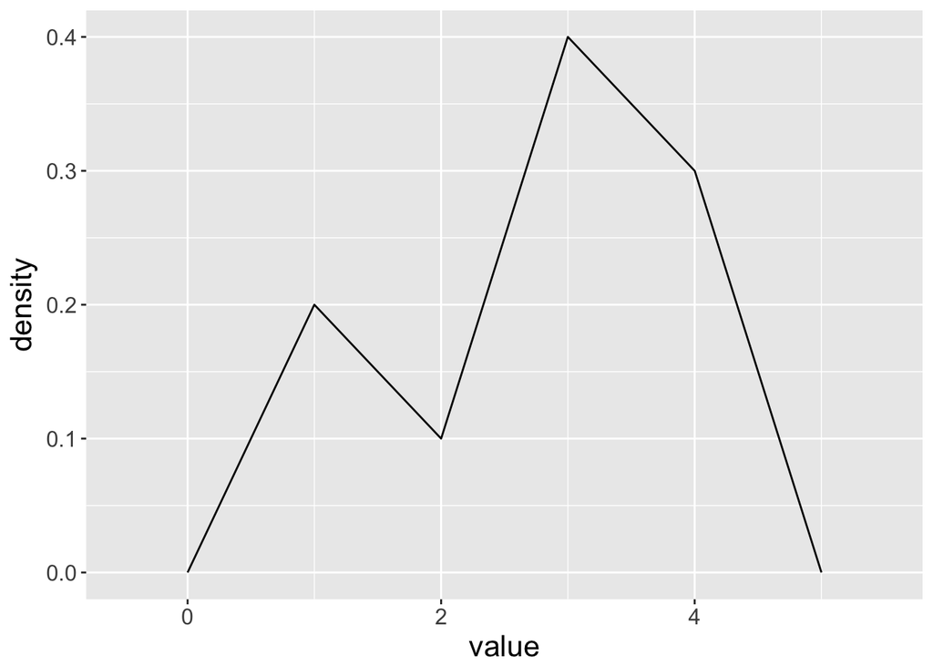

```r
ggplot(df, aes(value,..density..)) +
  geom_freqpoly(binwidth=1) +t
```

Plot the cumulative distribution.

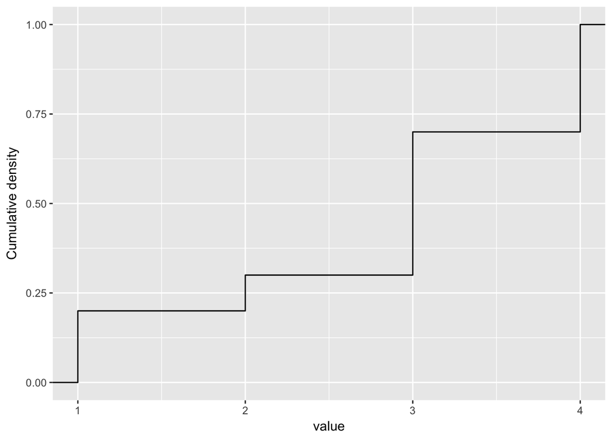

```r
ggplot(df, aes(value)) + stat_ecdf() + ylab('Cumulative density')
```

Get proportion of scores greater than 2

```r
greaterThanTwo=df$value>2
print('values:')
```

```
## [1] "values:"
```

```r
print(greaterThanTwo)
```

```
##  [1] FALSE FALSE FALSE  TRUE  TRUE  TRUE  TRUE  TRUE  TRUE  TRUE
```

```r
propGreaterThanTwo=mean(greaterThanTwo)
print(paste('proportion greater than two:',propGreaterThanTwo))
```

```
## [1] "proportion greater than two: 0.7"
```

```r
print(paste('Percentage greater than two:',100*propGreaterThanTwo))
```

```
## [1] "Percentage greater than two: 70"
```

Make a stem and leaf plot

```r
dfStemLeaf <- data.frame(value=c(8,8,9,10,12,12,14,18,21,22,23,25,25,30,32,51))

stem(dfStemLeaf$value)
```

```
##
##   The decimal point is 1 digit(s) to the right of the |
##
##   0 | 889
##   1 | 02248
##   2 | 12355
##   3 | 02
##   4 |
##   5 | 1
```

### Working with continuous values

First let’s show a histogram of ages in the dataset.

```r
# if the NHANES package isn't already installed then install it first
if (!require("NHANES")) install.packages("NHANES")
```

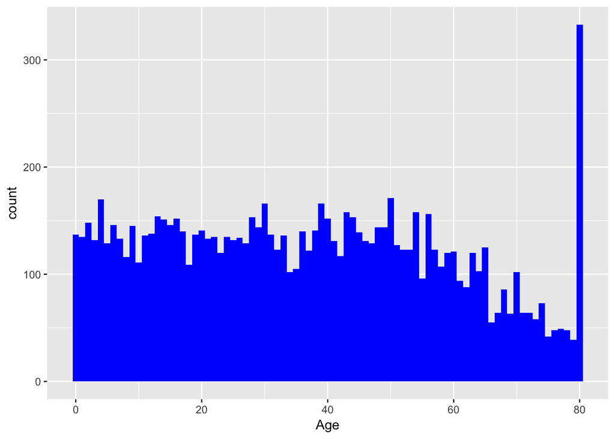

```r
library(NHANES)

ggplot(NHANES, aes(Age)) +
  geom_histogram(binwidth=1,fill='blue')
```

What’s up with the big spike at 80? Hint: Look at the help function for NHANES.

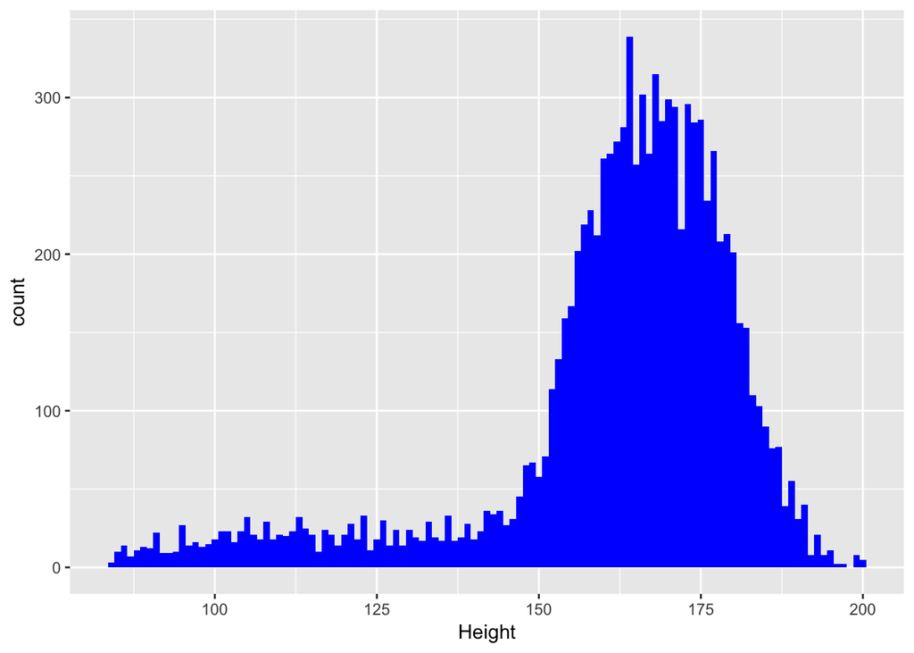

```r
# create a new variable with weight in pounds
NHANES$WeightPounds <- NHANES$Weight * 2.2

ggplot(NHANES, aes(Height)) +
  geom_histogram(binwidth=1,fill='blue')
```

Why is there a bump at the left?

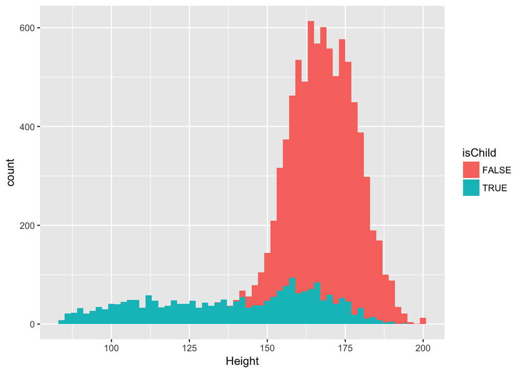

```r
NHANES$isChild <- NHANES$Age<18

ggplot(NHANES, aes(Height,fill=isChild)) +
  geom_histogram(binwidth=2)
```

### Idealized distributions

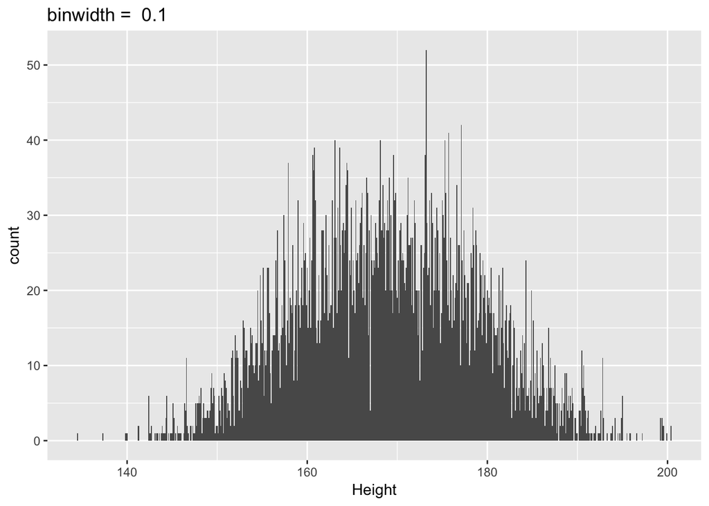

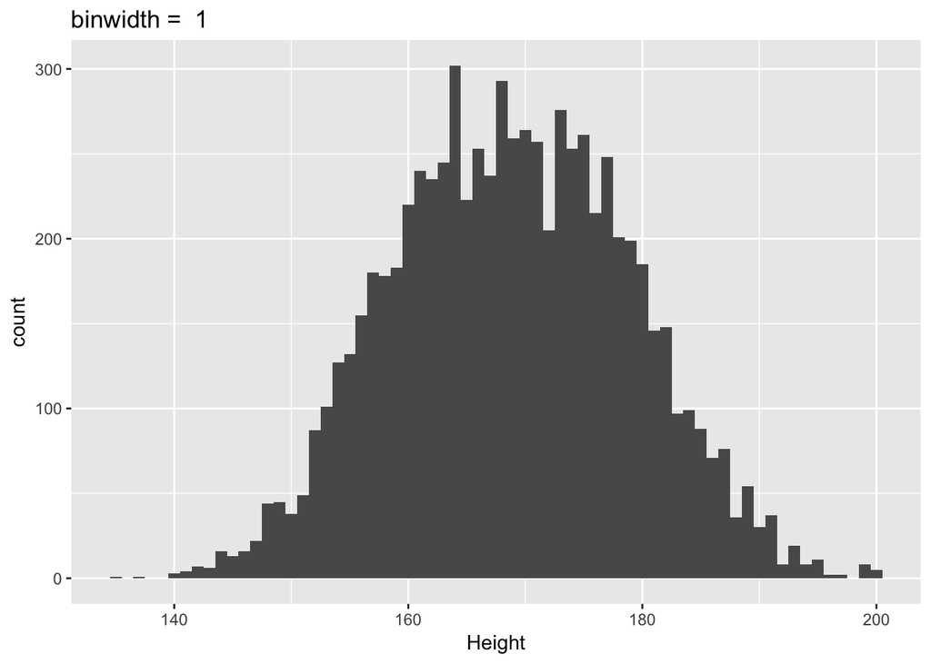

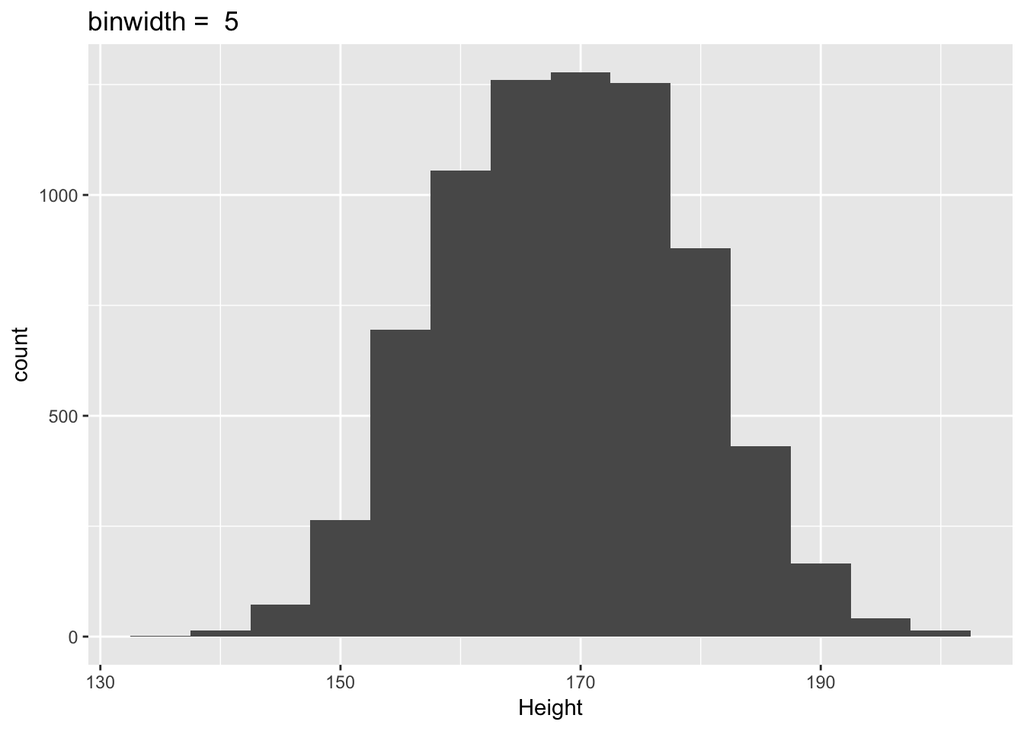

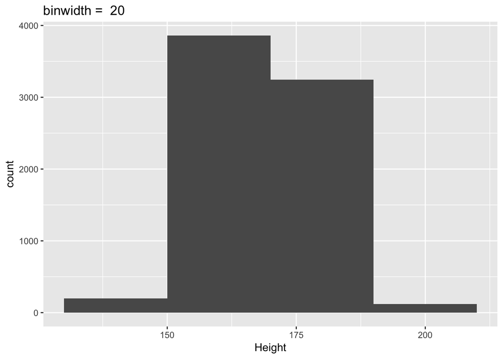

```r
NHANES_adult=subset(NHANES,subset=!isChild & Height!='NA')

for (bw in c(0.1,1,5,20)){
  p=ggplot(NHANES_adult, aes(Height)) +
    geom_histogram(binwidth=bw) + ggtitle(paste('binwidth = ',bw))
  print(p)
}
```

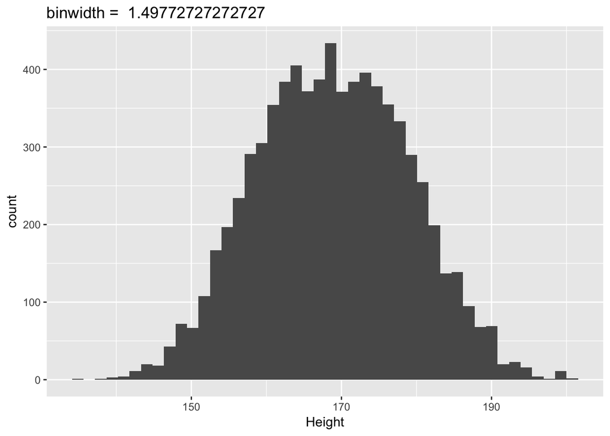

```r
rng=range(NHANES_adult$Height)
bw=(rng[2]-rng[1])/nclass.FD(NHANES_adult$Height)
ggplot(NHANES_adult, aes(Height)) +
    geom_histogram(bins=nclass.FD(NHANES_adult$Height)) + ggtitle(paste('binwidth = ',bw))
```

```r
print(paste('Optimal bin width by Freedman-Diaconis rule:',bw))
```

```
## [1] "Optimal bin width by Freedman-Diaconis rule: 1.49772727272727"
```

```r
height_mean <- mean(NHANES_adult$Height,na.rm=TRUE)
height_sd <- sd(NHANES_adult$Height,na.rm=TRUE)

print(height_mean)
```

```
## [1] 168.863
```

```r
print(height_sd)
```

```
## [1] 10.10583
```

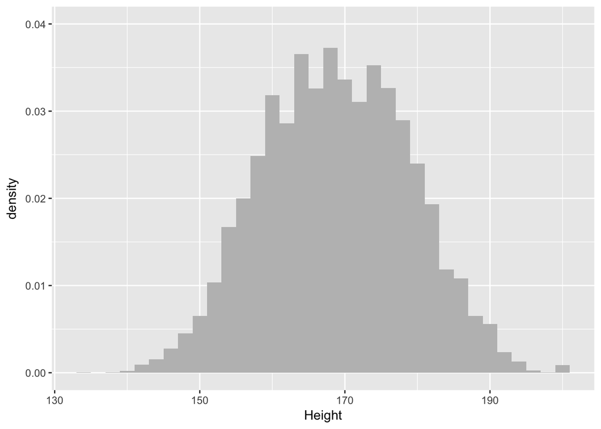

```r
ggplot(NHANES_adult, aes(Height)) +
  geom_histogram(aes(y=..density..),binwidth=2,
                 fill = "gray")  + ylim(0,0.04)
```

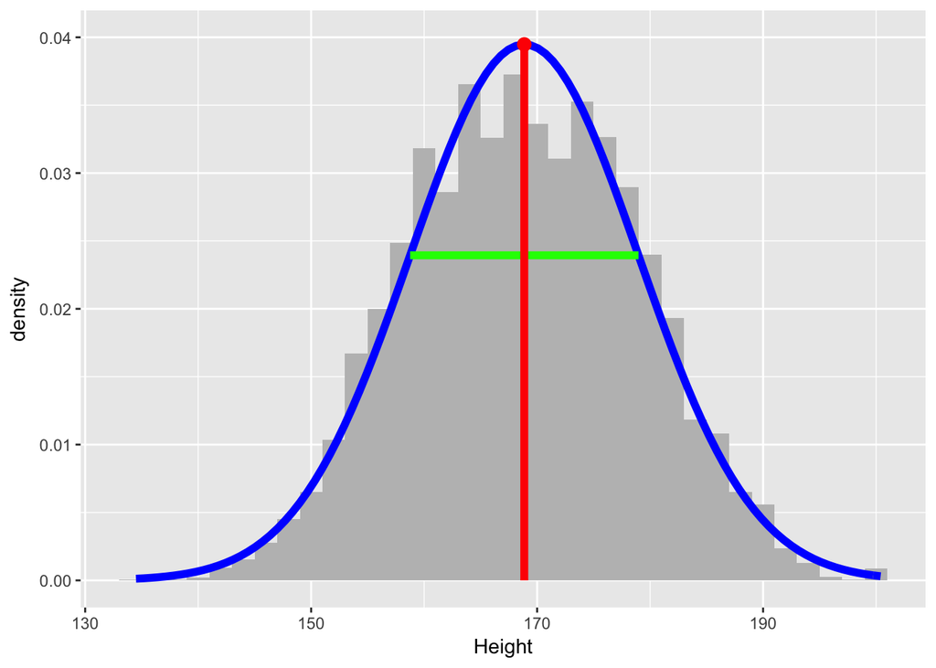

```r
sdcut=dnorm(height_mean-height_sd,mean=height_mean,sd=height_sd)
meancut=dnorm(height_mean,mean=height_mean,sd=height_sd)
ggplot(NHANES_adult, aes(Height)) +
  geom_histogram(aes(y=..density..),binwidth=2,
                 fill = "gray") +
  stat_function(fun = dnorm, args = list(mean = height_mean, sd = height_sd),color='blue',size=2) +
  ylim(0,0.04) +
  annotate('point',x=height_mean,y=meancut,color='red',size=3) +
  annotate('segment',x=height_mean-height_sd,xend=height_mean+height_sd,y=sdcut,yend=sdcut,color='green',size=2) +
  annotate('segment',x=height_mean,xend=height_mean,y=0,yend=meancut,color='red',size=2)
```

Display the cumulative distribution of heights.

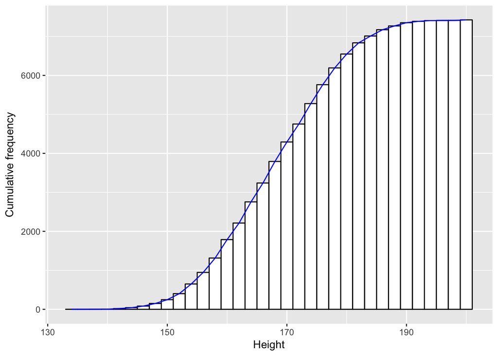

```r
ggplot(NHANES_adult, aes(Height)) +
  geom_histogram(aes(y=cumsum(..count..)),binwidth=2,
                 colour = "black",
                 fill = "white") +
       stat_bin(aes(y=cumsum(..count..)),geom="line",color="blue",binwidth=2) +
      ylab('Cumulative frequency')
```

Show it as a density rather than a frequency distribution.

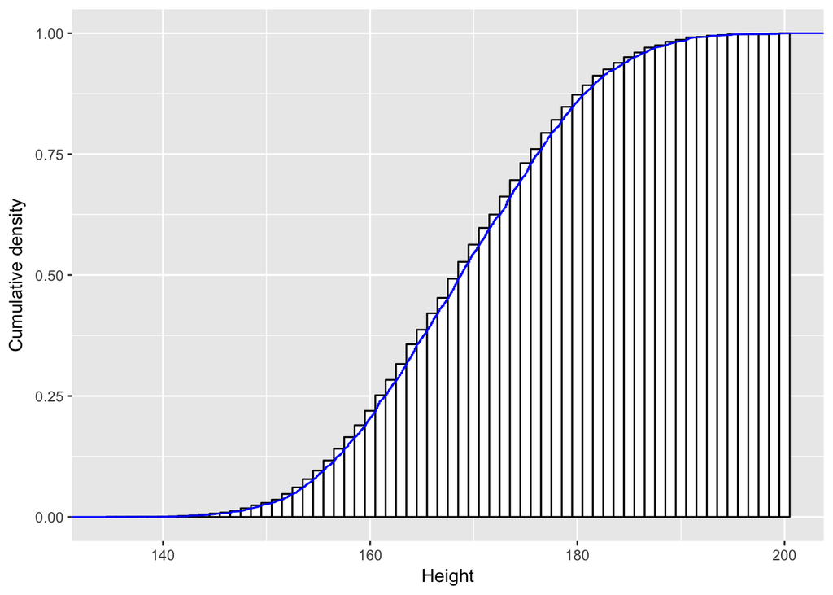

```r
ggplot(NHANES_adult, aes(Height)) +
  geom_histogram(aes(y=cumsum(..density..)),binwidth=1,
                 colour = "black",
                 fill = "white") +
        stat_ecdf(color='blue')   +
      ylab('Cumulative density')
```

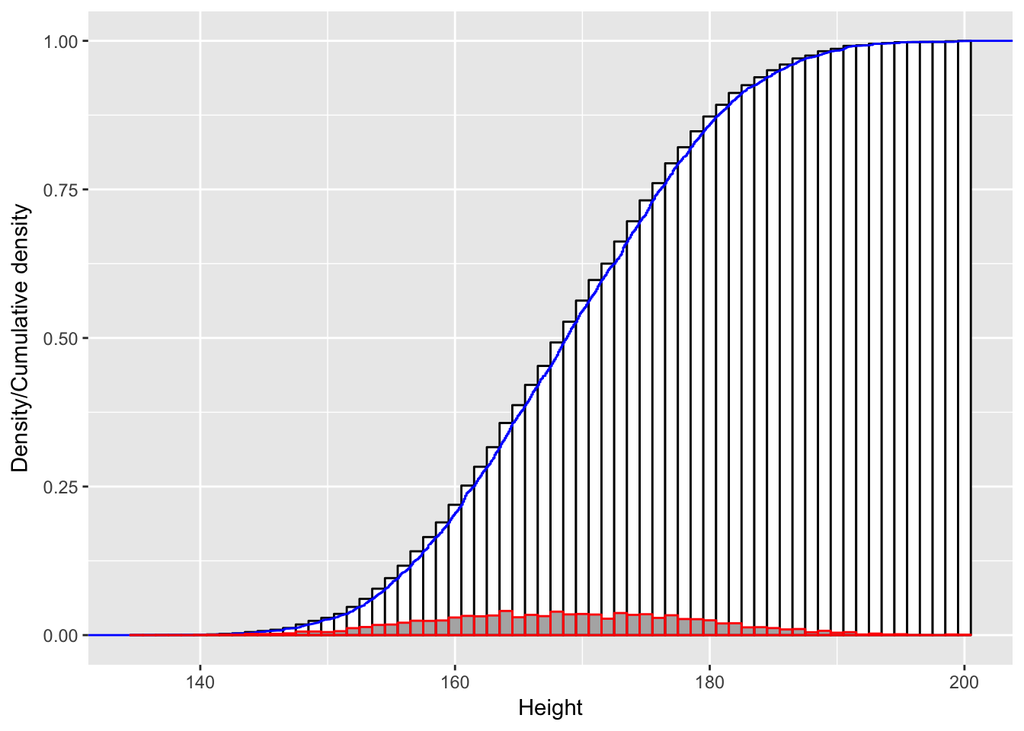

```r
# make a version with the distribution overlaid

ggplot(NHANES_adult, aes(Height)) +
  geom_histogram(aes(y=cumsum(..density..)),binwidth=1,
                 colour = "black",
                 fill = "white") +
        stat_ecdf(color='blue')   +
      ylab('Density/Cumulative density') +
  geom_histogram(aes(y=..density..),binwidth=1,color='red',alpha=0.5)
```

Not all variables are normally distributed. Ratio scale variables will often be skewed because they can’t be negative. Here is an example using wait times at SFO Terminal A from Jan-Oct 2017 (from https://awt.cbp.gov/).

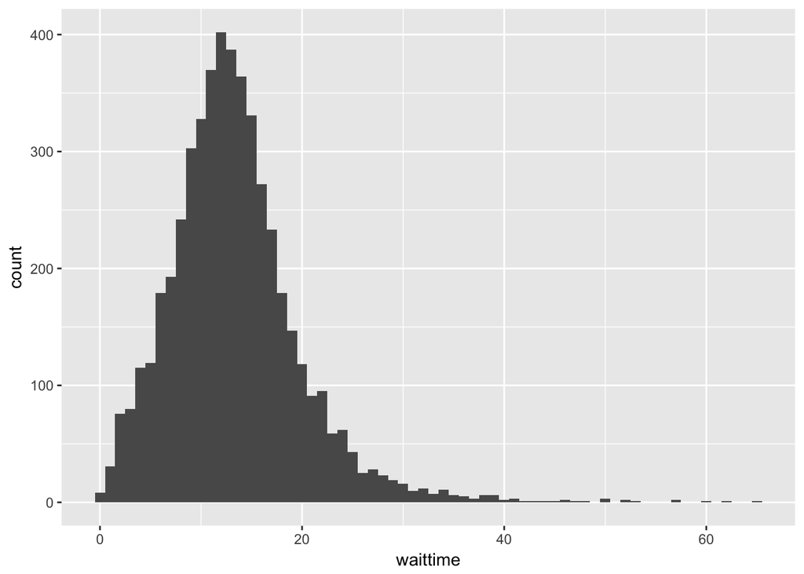

```r
waittimes=read.table('sfo_wait_times_2017.csv')
names(waittimes)=c('waittime')
ggplot(waittimes,aes(waittime)) +
  geom_histogram(binwidth=1)
```

Another example is variables that involve counts of smallish numbers of things.

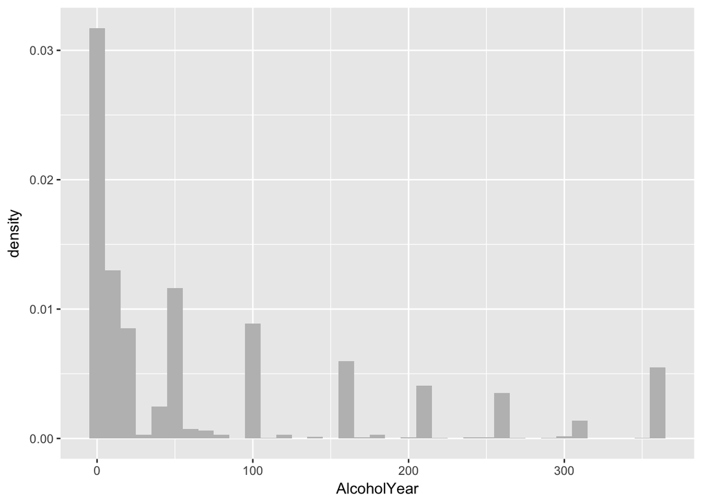

```r
ggplot(NHANES_adult, aes(AlcoholYear)) +
  geom_histogram(aes(y=..density..),binwidth=10,
                 fill = "gray")
```

### Long-tailed distributions

Sometimes distributions look very different from normal.

Load the Facebook friend data from the Stanford Large Network Database: https://snap.stanford.edu/data/egonets-Facebook.html

and plot the distribution of social network sizes.

```r
fbdata=read.table('facebook_combined.txt')
print(sprintf('found %d unique IDs',length(unique(fbdata[,1]))))
```

```
## [1] "found 3663 unique IDs"
```

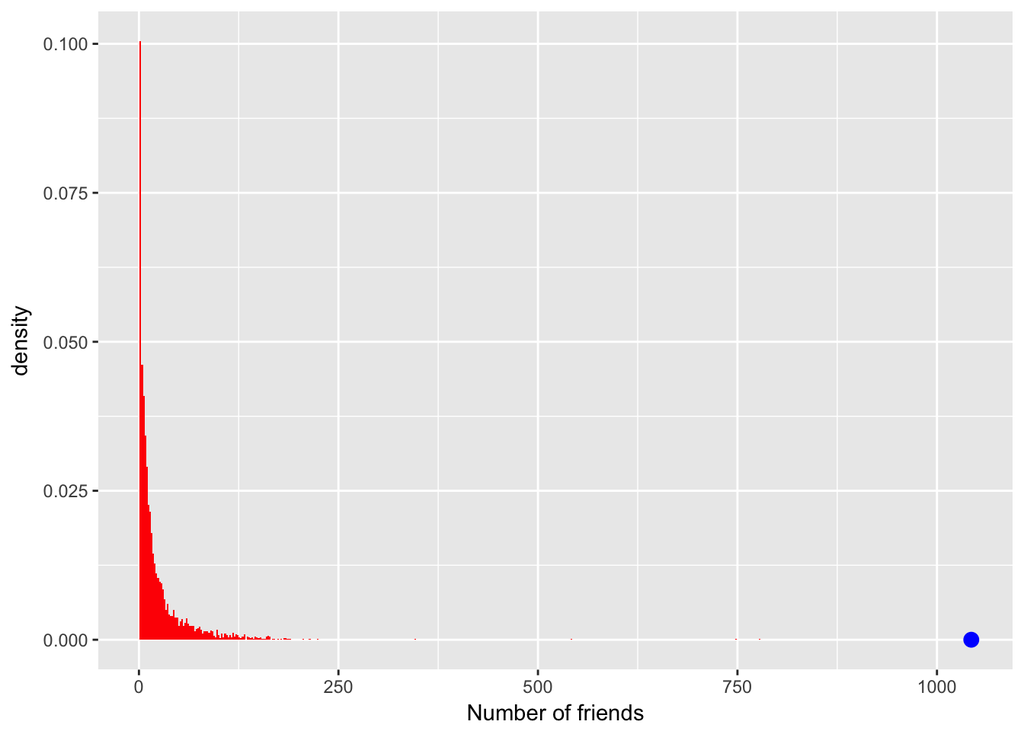

```r
# use the table function to compute how many times each individual ID shows up in the dataset
friends_table=table(fbdata[,1])
nfriends=as.data.frame(friends_table)
names(nfriends)=c('ID','Nfriends')

ggplot(nfriends, aes(Nfriends)) +
  geom_histogram(aes(y=..density..),fill = "red",binwidth=2)  +
  xlab('Number of friends') +
  annotate('point',x=max(nfriends$Nfriends),y=0,color='blue',size=3)
```

#### Logarithms

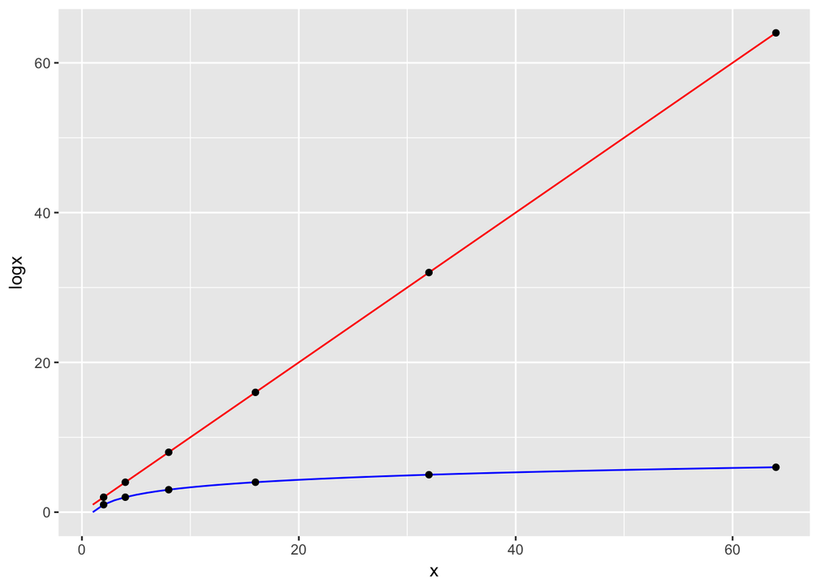

```r
x=seq(1,64)
p=ggplot(data.frame(x=x,logx=log2(x)),aes(x,logx)) +
  geom_line(color='blue') + geom_line(aes(x=x,y=x),color='red')
for (i in 1:6) {
  p=p+annotate('point',x=2**i,y=i) +
    annotate('point',x=2**i,y=2**i)
}
print(p)
```

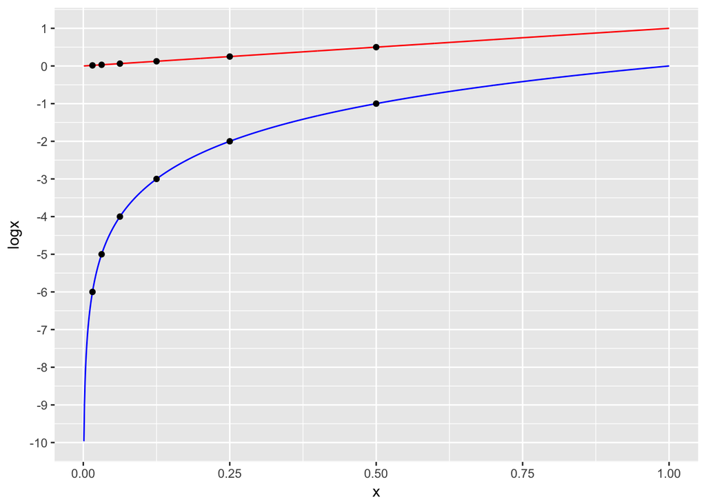

```r
x=seq(1.0,1e-4,-0.001)
p=ggplot(data.frame(x=x,logx=log2(x)),aes(x,logx)) +
  geom_line(color='blue') + geom_line(aes(x=x,y=x),color='red')
for (i in 1:6) {
  p=p+annotate('point',x=2**-i,y=-i) +
    annotate('point',x=2**-i,y=2**-i)
}
print(p+ scale_y_continuous(breaks=seq(-10,2,1)))
```

Plot the friend data on a log scale

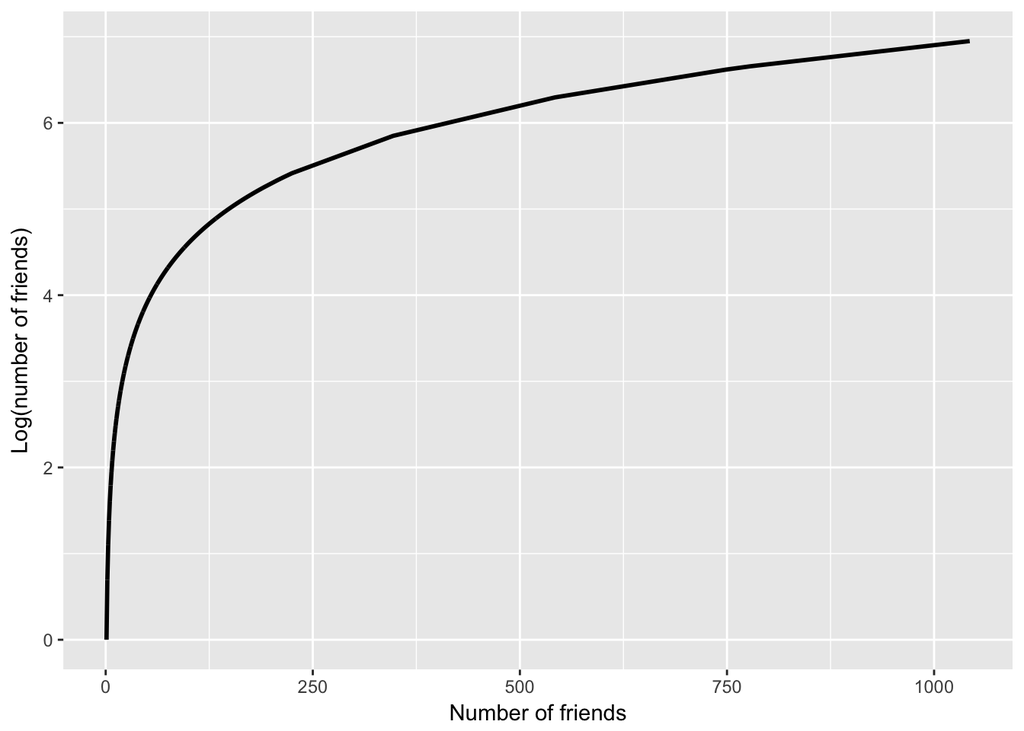

```r
nfriends$logNfriends=log(nfriends$Nfriends)

ggplot(nfriends, aes(Nfriends,logNfriends)) +
  geom_line(size=1) + xlab('Number of friends') +
  ylab('Log(number of friends)')
```

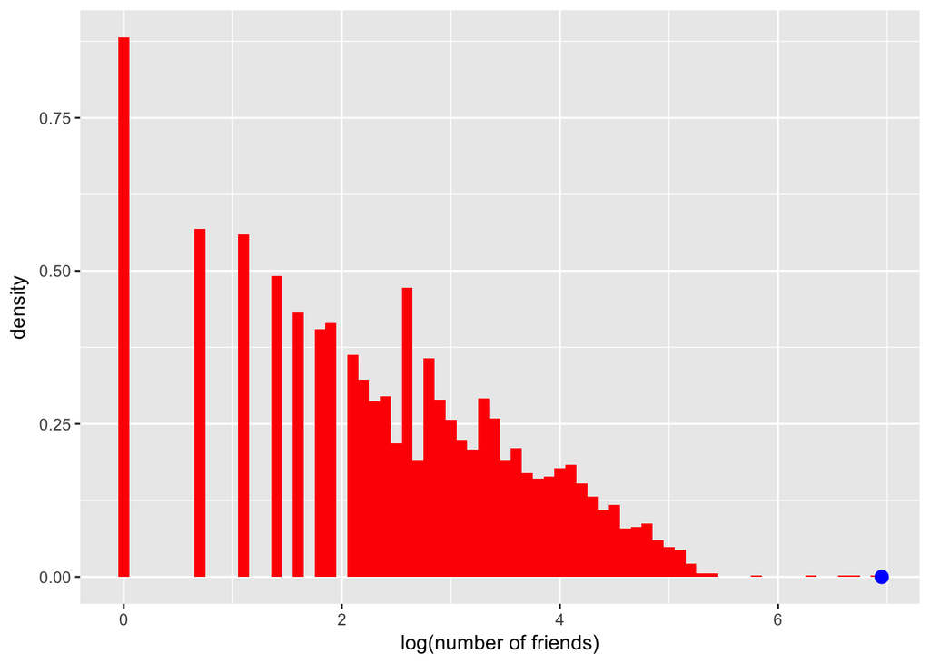

```r
ggplot(nfriends, aes(logNfriends)) +
  geom_histogram(aes(y=..density..),fill = "red",binwidth=0.1)  +
  xlab('log(number of friends)') +
  annotate('point',x=max(nfriends$logNfriends),y=0,color='blue',size=3)
```

#### Extra: Simulating social networks

Let’s see how this works using a simple simulation. We will start with two people and then add additional individuals one at a time. Each of these new individuals will be friends with either one or two people, with the likelihood of friendship based on the relative number of friends that one has. That is, the rich get richer. We simulate this process using the Barabasi-Albert graph simulator in the NetworkX python package (in prefattach_simulation.py). These results are saved to a file that we load here. We will also compare this to a social network of the same size where friendships are created randomly.

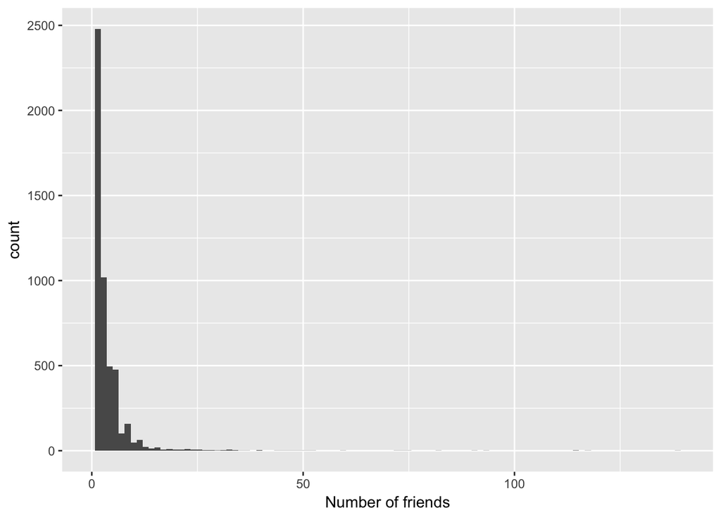

```r
degreeData=read.table('bagraph_degree.txt')
degreeDataRandom=read.table('randgraph_degree.txt')

ggplot(degreeData,aes(V1)) +
  geom_histogram(bins=100) + xlab('Number of friends') + xlim(0,140) #+
```

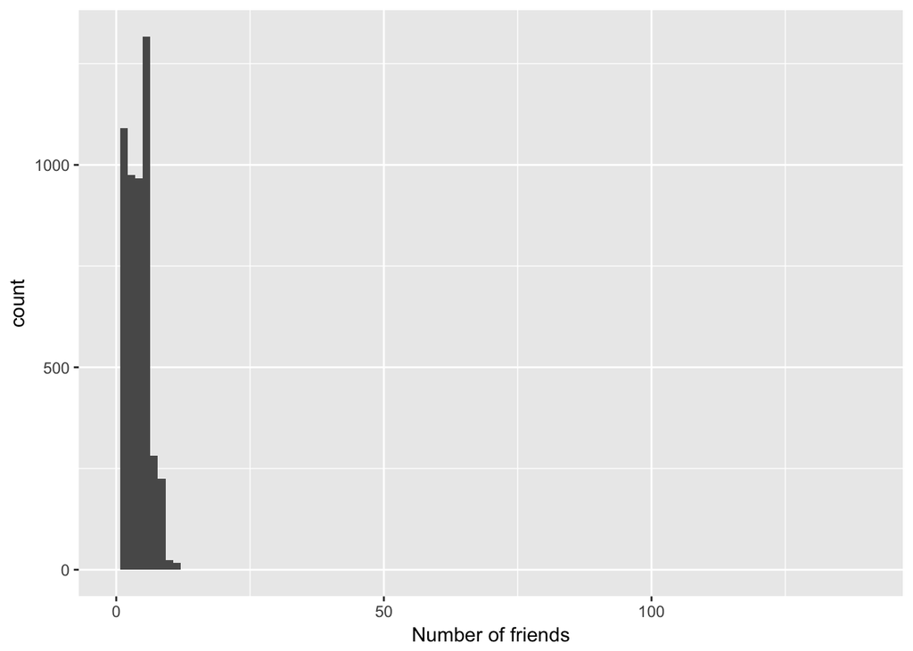

```r
  #geom_histogram(data=degreeDataRandom,aes(V1),bins=100,fill='blue')

ggplot(degreeDataRandom,aes(V1)) +
  geom_histogram(bins=100) + xlab('Number of friends') + xlim(0,140)
```

#### Household income

Let’s look at household income in the US. Income data come from the IPUMS Current Population Survey (https://cps.ipums.org/cps/index.shtml), which includes data from 126,118 households.

```r
# code used to prepare data originally - now we just load them directly
# data=read.table('cps_00001.csv',sep=',',header=TRUE)
# df=subset(data,select=c(YEAR,INCTOT))
# df=df %>% drop_na()
# df=df[df$INCTOT<99999999,]
# df=df[df$INCTOT>0,]
# save(df,file='cps_income.Rdata')
load('cps_income.Rdata')
```

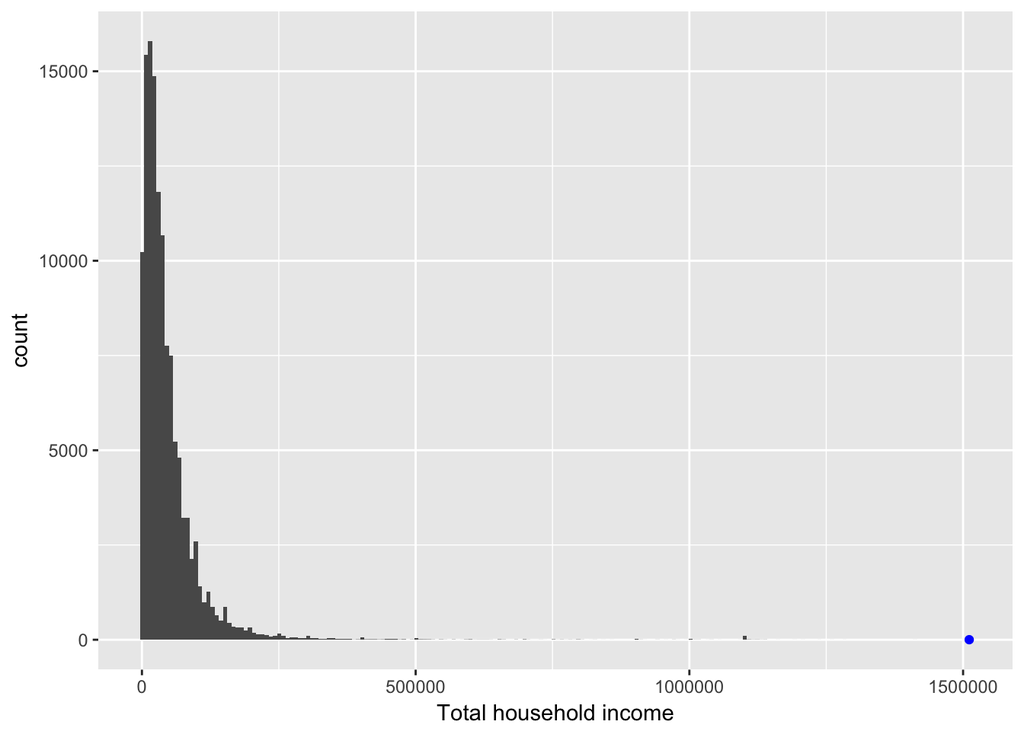

```r
ggplot(df,aes(INCTOT)) +
  geom_histogram(bins=200) + xlab('Total household income') +
  annotate('point',x=max(df$INCTOT),y=1,size=1.5,color='blue')
```

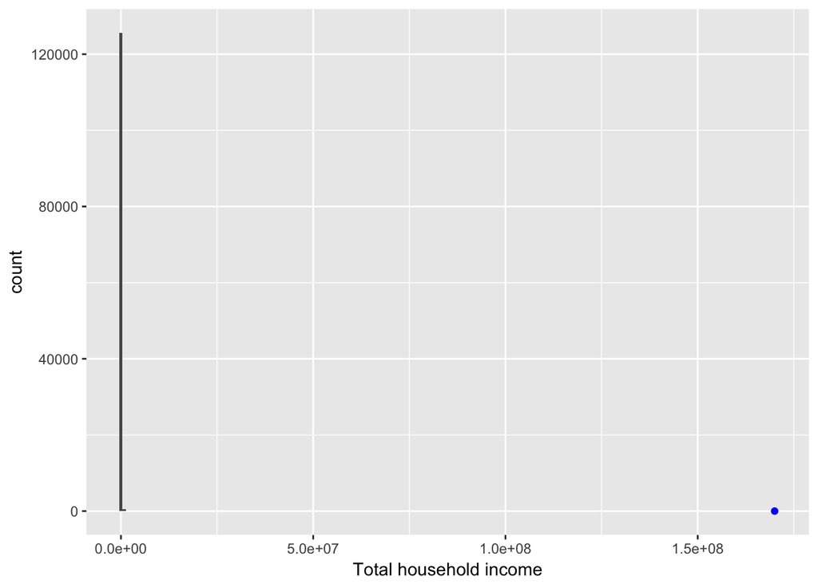

```r
# make a version that includes Taylor Swift at 170 million
ggplot(df,aes(INCTOT)) +
  geom_histogram(bins=200) + xlab('Total household income') +
  annotate('point',x=170000000,y=1,size=1.5,color='blue')
```

Let’s plot the same data as percentiles.

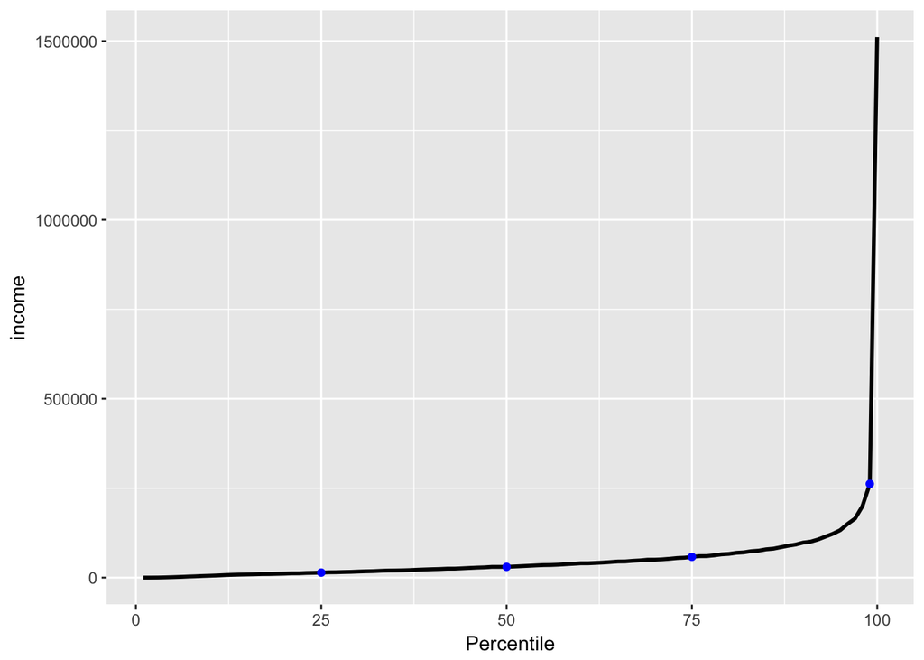

```r
percentileData=data.frame(pctile=seq(1,100),
                          income=quantile(df$INCTOT,seq(1,100)/100),
                          height=quantile(NHANES_adult$Height,seq(1,100)/100))
ggplot(percentileData,aes(pctile,income)) + xlab('Percentile') +
  geom_line(color='black',size=1) +
  annotate('point',x=25,y=quantile(df$INCTOT,0.25),color='blue') +
  annotate('point',x=50,y=quantile(df$INCTOT,0.5),color='blue') +
  annotate('point',x=75,y=quantile(df$INCTOT,0.75),color='blue') +
annotate('point',x=99,y=quantile(df$INCTOT,0.99),color='blue')
```

```r
print(quantile(df$INCTOT,c(0.25,0.5,0.75,0.99)))
```

```
##       25%       50%       75%       99%
##  14015.00  30045.00  57936.25 262048.00
```

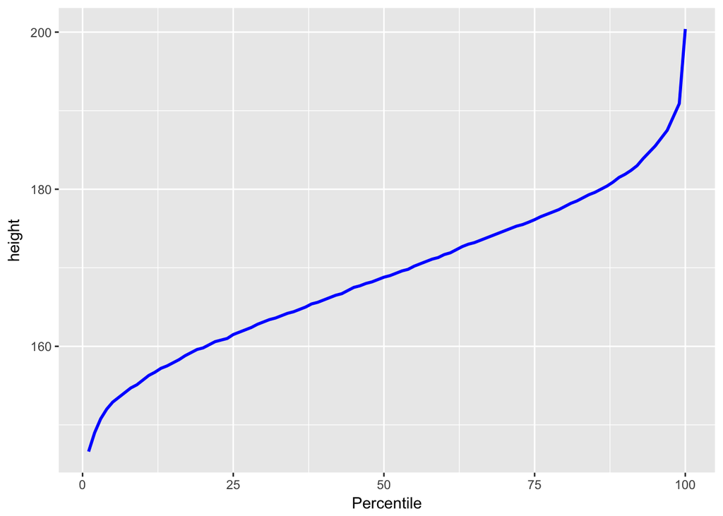

```r
ggplot(percentileData,aes(pctile,height)) + xlab('Percentile') +
  geom_line(color='blue',size=1)
```

#### Extra: Word frequency

data obtained from http://www.anc.org/data/anc-second-release/frequency-data/

```r
wfdata=read.table('ANC-written-count.txt',sep='\t',quote='"')
names(wfdata)=c('word','lemma','POS','count')
```

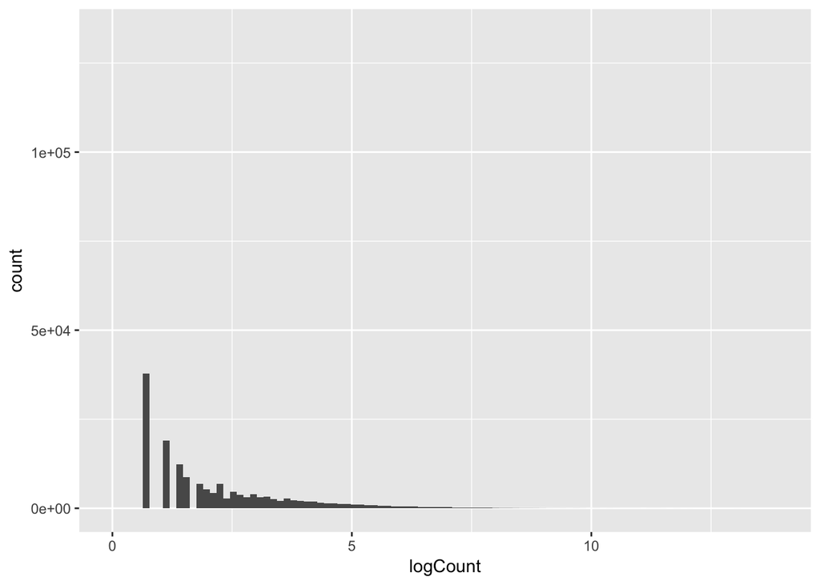

```r
wfdata$logCount=log(wfdata$count)
ggplot(wfdata,aes(logCount)) +
  geom_histogram(bins=100) + xlim(0,max(wfdata$logCount))
```